# Extreme Weather and Climate Change?

Does climate change influence extreme events?

EA30 Students, Pomona College

March 22, 2019

Updated: 2019-12-16 23:37:14

# What is Attribution Science?

Attribution Science is a subset of climate science that attempts to evaluate the effect of climate change on weather patterns, in particular extreme weather events. Determining the climate change signature on these extreme events relies a wide range of observations and data sources, such as weather instruments, records, and modeling, as well as, historic climate events and proxy data of weather.

For example, rivers can flood on an annual basis. However, the size of these floods will vary with rainfall. If climate change influences rainfall patterns, then we might expect to see flooding change. Wong (2019) describes how complicated this is in East Asia because the weather system there is one of the most complext in the world.

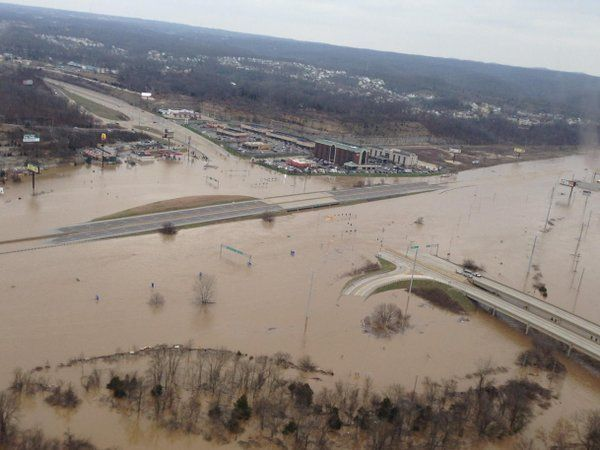

2015 Flood in Fenton, Missouri. Human developments in the flood plain are a recipe for disaster. But do the hazards of these activities increase in frequency or intensity with climate change? This is a question that “attribution science” tries to answer.

Unfortunately, climate science has become so politicized reports of extreme events, which can even lead to misunderstandings of these climate events. For example, Vance (2019) documents how social media has been used to make claims about extreme events that obscure important long-term trends. In particular, in the (US) South, climate change skepticism runs, as well as, the use of coal for electrical generation. However, this region may be may be hardest hit by the effects of climate change unless we curb CO<sub>2</sub> global emissions.

## Operationalizing Questions in Attribution Science

Asking how climate change influenced a certain extreme event is one of the first stages of attribution science. For example, after extensive flooding in Colorado in 2013, researchers formulated a testable hypothesis to evaluate the role of climate change on the flooding, but the results were contested.

Lai (2019) used the 2013 Colorado flood as a case study to discuss how weather records, weather modeling, and scientific research to understand the causes of the flood and why different scientists arrived at differing conclusions.

## Climate Change and the Built Environment

### Heat Waves and Blizzards in Urban Environments

Clark (2019) explored extreme events in Washington D.C. and their relationship to climate change.

Similarly, Randle (2019) evaluated the impact of extreme cold in Chicago it’s relationship the to the polar vortex.

Heat waves has important implications on urban environments. For example, Southern California will probably experience a dramatic increase in heat waves with climate change, which will have a wide range if social and ecological implications (Bullock Floyd 2019)

Public health included more than extreme events – Yi (2019) demonstrates that the urban heat island effect is a complex process. And in the context of Chicago and climate change, the concerns and strategies to reduce the impact of urban heat islands will require several tiers of policy changes.

### Attributions and Bias

Unfortunately, the regions that are selected for study are based on researcher interests, thus some events have been well studied and others virtually ignored (Huggel et al. 2016). Scientists don’t work in a vacuum and we often try to make connections to issues that we care about, but hopefully, we can address issues that many people care about.

Huggel, Christian, Ivo Wallimann-Helmer, Daithi Stone, and Wolfgang Cramer. 2016. “Reconciling Justice and Attribution Research to Advance Climate Policy.” *Nature Climate Change* 6 (10). Nature Publishing Group: 901.

## Fires in the West

### The Pacific Northwest

The impact of cliamte change in the Pacific Northwest and in the state of Washington has become increasingly poignant – in part because of the issues of fire and smoke. Generous (2019) evaluated fires in the Spokane region while Meyer 2019 summarized what scientists know about climate change and fires in the Seattle-Tacoma region.

### Wildfire Risks and WUIs in California

In Southern California, the climate is not simply warming or cooling. Thanks to ongoing changes in climate, the rainy season has begun a pendulum effect, swinging from storms and flooding to drought conditions almost yearly in a phenomenon known as ‘climate whiplash.’ The environmental impacts of this phenomenon are severe, including increased numbers of fires, floods, and droughts plaguing the region. Evidence for climate whiplash, as well as its effects and implications (Anderson 2019).

### Public Safety and Health

Kaufman (2019) acknowledges her commitment to the health and well being of New Yorks. In particular, she evaluates the role of climate change and the destructive nature of Hurricane Sandy (2012).

## Drought and Economic Impacts Nexus in the Southwest

Namachivayam (2019) examines the trend of rising temperatures in Albuquerque and their potential impact on drought in New Mexico.

### Tourism and Jobs

Budd (2019) describes the subtle plant phenology associated with climate change. In this case, the forests of New Hampshire may experience changes in how their fall season reaspond to a warming globe and possible economic impacts on the region.

# Previous EA30 Projects

Climate Change and Fires – Is this a red herring or the alarm alarmists have been warning about?

Why Climate Change Will Affect You Personally?

Climate Change and Logical Fallacies